# 02 - Chunk di codice

## Cosa sono

Sono quello che rende `RMarkdown` così “speciale”.

Permettono di integrare i documenti con i risultati delle analisi e con i codici usati per ottenerle (tutti i miei materiali supplementari alle riviste sono prodotti con `RMarkdown`)

Per crearli, basta usare la combinazione di tasti `Ctrl + Alt + i` (`Cmd + Alt + i` se si ha il Mac):

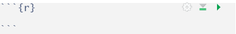

## Il file di default

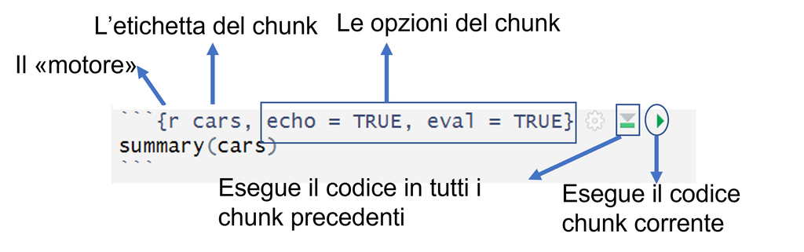

Il chunk

Tutte le opzioni che si vogliono dare al chunk (e.g., come mostrare i risultati, come mostrare le figure, se mostrare o meno le figure ecc.) vanno separate dalla virgola e scritte a mano

## Oppure

Oppure si selezionano le opzioni base desiderate dal menu che appare cliccando sulla rotellina del chunk stesso:

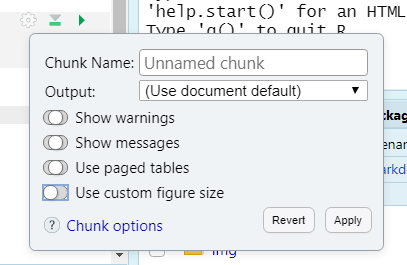

A [questa pagina](https://yihui.org/knitr/options/) è disponibile una lista esaustiva degli argomenti dei chunk di codice

Stessa cosa ma più schematica disponibile [qui](https://www.rstudio.com/wp-content/uploads/2015/03/rmarkdown-reference.pdf?_ga=2.224317531.1994910762.1649682827-1292953261.1617471531)

## Setup chunk

Qui vanno specificate tutte le opzioni di default che vogliamo applicare al nostro documento, i pacchetti che pensiamo di usare per le nostre analisi, i dati, gli environment (per fare prima) eccetera.

Un esempio di setup chunk è:

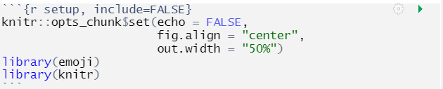

A meno che non venga specificato altrimenti, ogni chunk del documento seguirà le opzioni di default specificate nel setup chunk

## Warning

L’environment di `R` e l’environment di `RMarkdown` sono due cose dievrse

Il fatto che voi vediate degli oggetti nel vostro environment come nell’esempio qui sotto non implica che siano importati automaticamente dentro RMarkdown

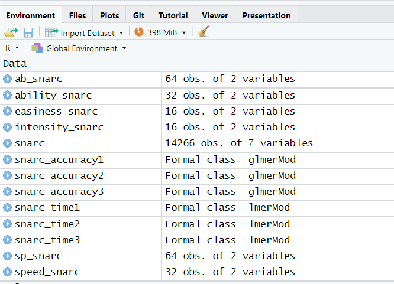

R environment

[figure not shown]

RMarkdown

## Warning I

Dovete ogni volta scrivere il codice per generare l’environment in modo che corra *senza errori*

Un’altra opzione è di importare l’environment salvato con il comando `load()`

## Your turn!

- Importate il vostro dataset nel setup chunk e assegnatelo a un oggetto:

```r
> data(nome_dataset)
> dati = nome_dataset
```

- Create un nuovo chunk dove esplorate il dataset (`head(dati)`)

ADVANCED

- Fate sparire il codice di `R` dall’output
- Salvate l’environment di `R` e richiamatelo nel setup chunk (hint: `load()`)

## Codice e risultati

## Codice eseguito e risultati mostrati

````
```{r, echo=TRUE, eval=TRUE}
ggplot(rock,
       aes(y=peri,x=shape, color =shape, size = peri)) + geom_point() +
  theme_bw() + theme(legend.position = "none")

```
````

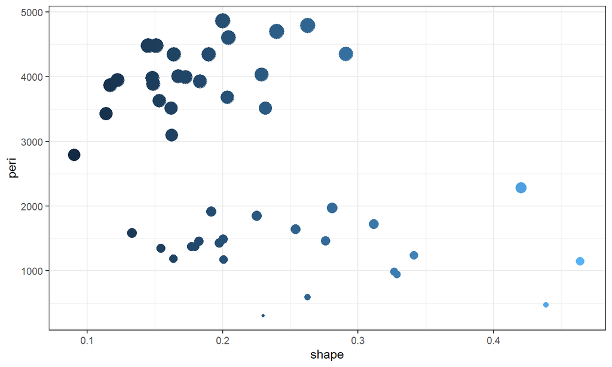

```r
> ggplot(rock, aes(y = peri, x = shape, color = shape, size = peri)) + geom_point() +
+     theme_bw() + theme(legend.position = "none")
```

## Risultati senza codice

````
```{r, echo=FALSE, eval=TRUE}
ggplot(rock,
       aes(y=peri,x=shape, color =shape, size = peri)) + geom_point() +
  theme_bw() + theme(legend.position = "none")

```
````

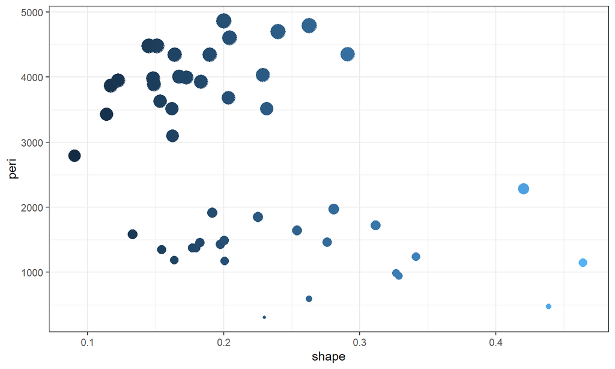

## Codice senza risultati (non eseguito)

````
```{r, echo=TRUE, eval=FALSE}
ggplot(rock,
       aes(y=peri,x=shape, color =shape, size = peri)) + geom_point() +
  theme_bw() + theme(legend.position = "none")
```
````

```r
> ggplot(rock, aes(y = peri, x = shape, color = shape, size = peri)) + geom_point() +
+     theme_bw() + theme(legend.position = "none")
```

## Codice eseguito, nessun risultato, nessun codice

````
```{r, include=FALSE}
library(ggplot2)
```
````

Non appare niente, non sono prodotti risultati visibili

L’opzione `include=FALSE` solitamente viene usata nel setup chunk e in tutti quei chunk di cui non interessa vedere un risultato ma che contengono un codice importante

## Messaggi di errore, warning, messaggi

- Molti pacchetti di `R` mostrano dei messaggi quando vengono caricati o quando viene usata qualche funzione. Per toglierli: `message=FALSE`
- Per togliere i warning (ad esempio quando usiamo `lme4` e fittiamo modelli molto complessi): `warning=FALSE`
- Per togliere i messaggi di errore (e.g., viene chiamato un oggetto che non esiste): `error=FALSE`

[output not shown]

⚠️ i messaggi di errore/warning sono spariti, gli errori che li causano esistono ancora!!!

## `eval=FALSE` vs. `results='hide'`

`eval=FALSE`

- Il codice **non** viene eseguito
- Se ci sono degli errori, non ve ne accorgete
- Particolarmente utile quando si vuole spiegare un codice molto complesso (ma dovete essere sicuri che funzioni)

`results='hide'`

- Il codice **viene** eseguito
- Se ci sono degli errori il codice non va
- Particolarmente utile quando si vuole spiegare un codice più semplice

## Risultati un po’ più carini

Di default, i risultati vengono mostrati così:

```
##   area    peri     shape perm
## 1 4990 2791.90 0.0903296  6.3
## 2 7002 3892.60 0.1486220  6.3
## 3 7558 3930.66 0.1833120  6.3
```

````
```{r, comment=" "}
rock
```
````

```
      area     peri     shape   perm
  1   4990 2791.900 0.0903296    6.3
  2   7002 3892.600 0.1486220    6.3
  3   7558 3930.660 0.1833120    6.3
  4   7352 3869.320 0.1170630    6.3
  5   7943 3948.540 0.1224170   17.1
  6   7979 4010.150 0.1670450   17.1
  7   9333 4345.750 0.1896510   17.1
  8   8209 4344.750 0.1641270   17.1
  9   8393 3682.040 0.2036540  119.0
  10  6425 3098.650 0.1623940  119.0
  11  9364 4480.050 0.1509440  119.0
  12  8624 3986.240 0.1481410  119.0
  13 10651 4036.540 0.2285950   82.4
  14  8868 3518.040 0.2316230   82.4
  15  9417 3999.370 0.1725670   82.4
  16  8874 3629.070 0.1534810   82.4
  17 10962 4608.660 0.2043140   58.6
  18 10743 4787.620 0.2627270   58.6
  19 11878 4864.220 0.2000710   58.6
  20  9867 4479.410 0.1448100   58.6
  21  7838 3428.740 0.1138520  142.0
  22 11876 4353.140 0.2910290  142.0
  23 12212 4697.650 0.2400770  142.0
  24  8233 3518.440 0.1618650  142.0
  25  6360 1977.390 0.2808870  740.0
  26  4193 1379.350 0.1794550  740.0
  27  7416 1916.240 0.1918020  740.0
  28  5246 1585.420 0.1330830  740.0
  29  6509 1851.210 0.2252140  890.0
  30  4895 1239.660 0.3412730  890.0
  31  6775 1728.140 0.3116460  890.0
  32  7894 1461.060 0.2760160  890.0
  33  5980 1426.760 0.1976530  950.0
  34  5318  990.388 0.3266350  950.0
  35  7392 1350.760 0.1541920  950.0
  36  7894 1461.060 0.2760160  950.0
  37  3469 1376.700 0.1769690  100.0
  38  1468  476.322 0.4387120  100.0
  39  3524 1189.460 0.1635860  100.0
  40  5267 1644.960 0.2538320  100.0
  41  5048  941.543 0.3286410 1300.0
  42  1016  308.642 0.2300810 1300.0
  43  5605 1145.690 0.4641250 1300.0
  44  8793 2280.490 0.4204770 1300.0
  45  3475 1174.110 0.2007440  580.0
  46  1651  597.808 0.2626510  580.0
  47  5514 1455.880 0.1824530  580.0
  48  9718 1485.580 0.2004470  580.0
```

## Risultati un po’ più carini PT. II

Il codice si può troncare in modo che non venga quell’orrore che avete visto:

Setup chunk:

```r
> hook_output <- knitr::knit_hooks$get("output")
>
> knitr::knit_hooks$set(output = function(x, options) {
+     if (!is.null(n <- options$out.lines)) {
+         x <- xfun::split_lines(x)
+         if (length(x) > n) {
+             # truncate the output
+             x <- c(head(x, n), "....\n")
+         }
+         x <- paste(x, collapse = "\n")
+     }
+     hook_output(x, options)
+ })
```

Nel chunk che volete tagliare:

````
```{r, comment=" ", out.lines=4}
rock
```
````

```
      area     peri     shape   perm
  1   4990 2791.900 0.0903296    6.3
  2   7002 3892.600 0.1486220    6.3
  3   7558 3930.660 0.1833120    6.3
....
```

Ricodate che una delle righe che volete mostrate è “mangiata” dai nomi delle colonne

## Your turn!

- Create un nuovo chunk per il summary dei dati `summary(dati)` **senza** codice e con “NA” al posto degli hashtag nell’output
- Nuovo chunk dove eseguite il codice del vostro dataset che trovate [qui](https://ottaviae.github.io/CorsoRmarkdown/Datasets-Codici.html) (non fate la regressione e il grafico) **ma non mostrate né il codice né i risultati**
- Nuovo chunk dove eseguite il codice del grafico (`plot(data$y ~ data$x)`) **senza** codice
- Nuovo chunk dove mostrate il codice del grafico (`plot(data$y ~ data$x)`) **senza** risultati
- Tagliate l’output del vostro dataset in modo che vengano mostrate le prime 10 osservazioni

## Le tabelle

## La sintassi classica (Don’t panic)

```markdown
| Colonna 1 | Colonna 2 | Colonna 3 |
|-----------|-----------|-----------|
| 1         | 2         | 3         |
| 4         | 5         | 6         |
```

Che mi dà:

| Colonna 1 | Colonna 2 | Colonna 3 |
| --- | --- | --- |
| 1 | 2 | 3 |
| 4 | 5 | 6 |

Ci sono dei [compilatori automatici](https://www.tablesgenerator.com/markdown_tables#) che ci risparmiano la fatica, ma non è comunque il massimo

Stessa sintassi in `html` e `PDF`

## Integrare con `R`!

Ci sono diversi pacchetti che ci permettono di creare tabelle direttamente dai dataset senza fare fatica:

- [xtable](https://cran.r-project.org/web/packages/xtable/vignettes/xtableGallery.pdf)
- [stargazer](https://cran.r-project.org/web/packages/stargazer/vignettes/stargazer.pdf) ❤️
- [sjPlot](https://cran.r-project.org/web/packages/sjPlot/index.html) (per le tabelle di correlazione non c’è niente di meglio)
- [kable e kableExtra](https://cran.r-project.org/web/packages/kableExtra/vignettes/awesome_table_in_html.html)

In pratica, noi facciamo le nostre analisi e il pacchetto scelto le sistema in tabelle pronte all’uso!

## Tabelle senza fatica

Semplicemente l’output di `R`:

```r
> (summary_cars = rock %>%
+     group_by(perm) %>%
+     summarise(mean = mean(peri), sd = sd(peri), min = min(peri), max = max(peri)))
```

```
## # A tibble: 12 × 5
##      perm  mean    sd   min   max
##     <dbl> <dbl> <dbl> <dbl> <dbl>
##  1    6.3 3621.  553. 2792. 3931.
##  2   17.1 4162.  213. 3949. 4346.
##  3   58.6 4685.  174. 4479. 4864.
....
```

😄 rapido, efficace, colpo d’occhio

😭 Nella tesi non sta molto bene

## `stargazer` ❤️

😄 Fa in automatico i summary dei dataset

😄 Sistema in tabella i risultati dei modelli

😄 Stessa sintassi per html e PDF

😄 Perfetto per model comparison

😢 Non va bene per riportare le tabelle di summary preparate da noi.

🥹 è ottimmizzato per LaTex (ossia per produrre i PDF).

FONDAMENTALE:

````
```{r, results='asis'}

```
````

## `stargazer` summary

````
```{r, results='asis'}
library(stargazer)
stargazer(rock, type="latex", summary = TRUE,
           title= "Tabella di summary", digits = 2, header=FALSE)
```
````

[output not shown]

## `stargazer` model

```r
> m1 = lm(peri ~ perm, data = rock)
> stargazer(m1, type = "html", summary = TRUE, title = "Risultati del modello", digits = 2,
+     header = FALSE)
```

**Risultati del modello**

|  | *Dependent variable:* |
| --- | --- |
|  | peri |
| perm | -2.42*** |
|  | (0.32) |
| Constant | 3,685.77*** |
|  | (195.06) |
| Observations | 48 |
| R<sup>2</sup> | 0.55 |
| Adjusted R<sup>2</sup> | 0.54 |
| Residual Std. Error | 975.40 (df = 46) |
| F Statistic | 55.25*** (df = 1; 46) |
| *Note:* | p<0.1; p<0.05; p<0.01 |

## `stargazer` model comparison

```r
> m0 = lm(peri ~ 1, data = rock)
> m1 = lm(peri ~ perm, data = rock)
> stargazer(m0, m1, type = "html", title = "Model comparison", digits = 2, intercept.top = TRUE,
+     intercept.bottom = FALSE, header = FALSE)
```

**Model comparison**

|  | *Dependent variable:* |  |
| --- | --- | --- |
|  | peri |  |
|  | (1) | (2) |
| Constant | 2,682.21*** | 3,685.77*** |
|  | (206.64) | (195.06) |
| perm |  | -2.42*** |
|  |  | (0.32) |
| Observations | 48 | 48 |
| R<sup>2</sup> | 0.00 | 0.55 |
| Adjusted R<sup>2</sup> | 0.00 | 0.54 |
| Residual Std. Error | 1,431.66 (df = 47) | 975.40 (df = 46) |
| F Statistic |  | 55.25*** (df = 1; 46) |
| *Note:* | p<0.1; p<0.05; p<0.01 |  |

## Your turn!

- Tabella di summary del vostro dataset con 3 decimali
- Tabella di summary del vostro modello di regressione
- Caption per ognuna delle tabelle

ADVANCED

- Tabella di model comparison con modello nullo `m0` (`m0 = lm(y ~ 1, data = dati)`)

## Codice (e risultati) nel testo

Avete visto che nelle mie slide appaiono degli elementi scritti con la formattazione del codice di `R`

Ottenerli è molto semplice: `` `R` `` mi restituisce `R`

Ma molto di più: `` `r mean(rock$peri)` `` mi restituisce 2682.2119375 (Provateci!)

Se in un chunk precedente avessimo assegnato `x = mean(mtcars$mpg)`, avrremmo potuto semplicemente scrivere `` `r x` ``

## Codice, equazioni e codice nelle equazioni

\[\bar{X} = \frac{\displaystyle\sum_{i=1}^{n}x_i}{n}\]

Per `peri`:

\[\bar{X} = \frac{\displaystyle\sum_{i=1}^{n}x_i}{n} = \frac{1.2874617\times 10^{5}}{48} = 2682.21\]

`` $\frac{`r round(sum(rock$peri),2)`}{`r nrow(rock)`} = `r round(round(sum(rock$peri),2)/nrow(rock), 2)`$ ``

## Your turn!

- Provate a scrivere la formula per standardizzare la variabile \(y\) sup:

\[z = \frac{x_i - \bar{X}}{sd}\]

- Standardizzate il primo valore della \(y\) del vostro dataset e riportate il risultato nell’equazione